# Generating random points within a polygon

There are some cases where you might be interested in the distance from a bunch of different points within a polygon. Spatial sampling generates a sample of random points.

# Required packages

This example uses the following packages

```r
library(tidyverse)
library(sf)
library(tidycensus)
```

# Load some sample data

I’ll start by downloading census tract boundaries in San Luis Obispo County, with a variable indicating the population of each tract. There is one tract in the county with an empty geometry (no polygon boundary defined), so I’m going to filter that one.

```r
tracts <- get_decennial(year = 2020,
                        geography = "tract",
                        variables = c(Population = "P2_001N"),
                        output = "wide",
                        state = "CA",
                        county = "San Luis Obispo",
                        geometry = TRUE) %>%
  filter(!st_is_empty(.))
```

Here is a map of the tracts, with the variation in color representing the variation in population.

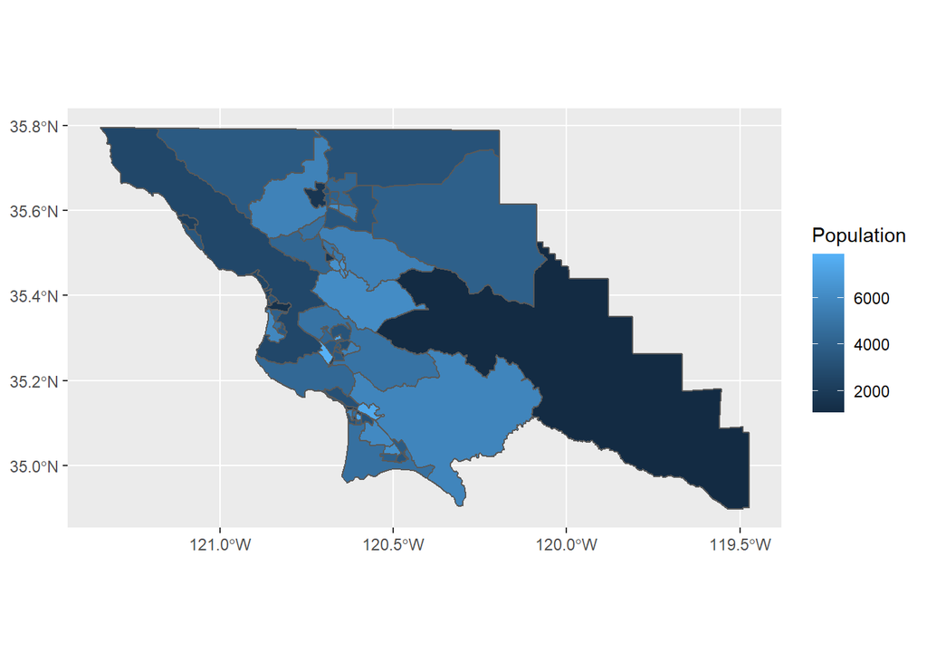

```r
ggplot(tracts) +
  geom_sf(aes(fill = Population))
```

# Generate random points

I can use `st_sample()` to generate a random set of points where each point represents 100 people. The `size` argument is the number of points I want in each tract. To get one point per hundred people, I’ll divide the population by 100. I’ll use the ceiling function to round up to the nearest whole number.

Keep in mind that the points are randomly generated. If you do this more than once, you won’t end up with points in the same location each time.

```r
people_pts <- st_sample(tracts,
                        size = ceiling(tracts$Population/100))
```

# Map

This can be a more intuitive way to display population on a map. And you can also use these random points to show variation in distance if you want to.

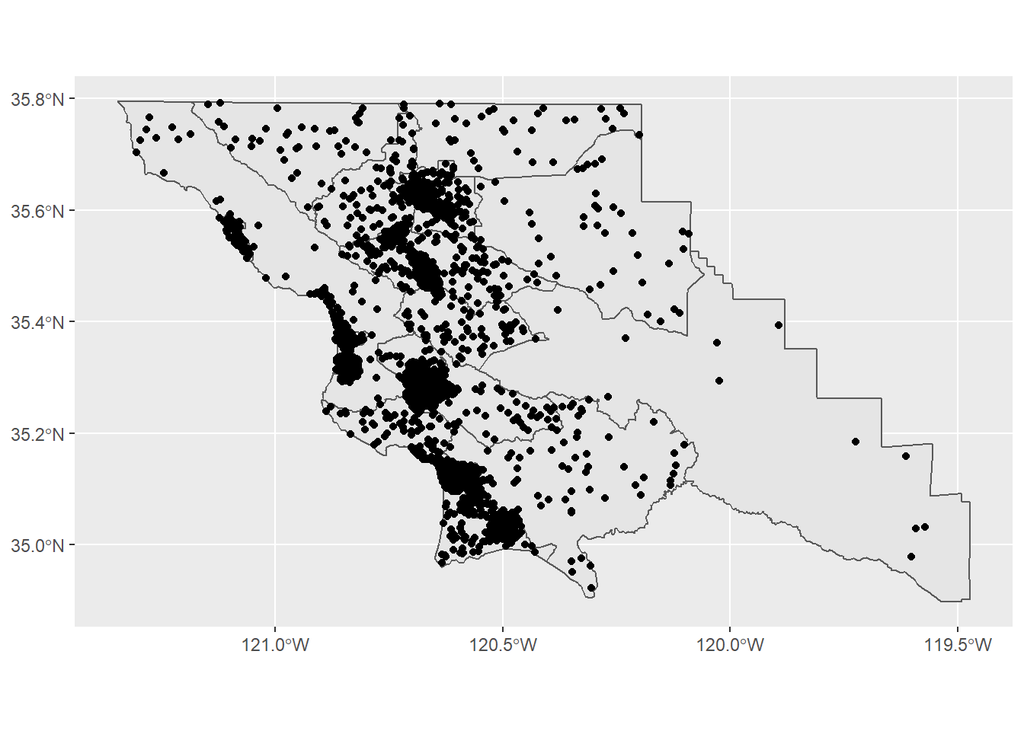

```r
ggplot() +
  geom_sf(data = tracts) +
  geom_sf(data = people_pts)
```